# Tuolumne River

Mark Tompkins

August 2024

## Future Data Improvement

None expected.

## Instream Spawning and Rearing Habitat

**Data Source:** [Methods for Quantifying Existing and Future Suitable Habitat for Fall-run Chinook Salmon, 2024](https://va-hrl-docs.s3.amazonaws.com/tuolumne/Tuolumne+River+VA+Habitat+Modeling+for+SBR+final+revision+20240802.pdf)

Instream spawning and rearing habitat for Fall Run Chinook Salmon in the Tuolumne River were provided by William Sears and Tuolumne parties as part of the Healthy Rivers and Landscapes modeling effort. The TUFlow modeling report from the FERC relicensing, which describes the process for developing the 1D/2D surface from which rasters of depth and velocity were derived for the entire 50 mile reach of the lower Tuolumne River. These were provided in units of suitable acres.

### Steelhead

Steelhead were assigned Fall Run Chinook values.

### Spawning and Rearing Data

The instream spawning and rearing habitat data described above for Fall Run Chinook Salmon (FR) were used for Steelhead (ST). Units are in suitable acres and converted to square meters. Rearing curve provided instream and floodplain combined (with a floodplain inundation threshold of `1000 cfs`). Instream rearing was set to be its value at `1000cfs` for all values above the threshold. Tuolumne parties also provided wetted area, which was not functionalized because it did not represent suitable area.

Header Descriptions: flow_cfs = flow in cubic feet per second, FR_fry_sqm = Fall Run Chinook fry (square meters), FR_juv_sqm = Fall Run Chinook Juvenile (square meters), FR_spawn_sqm = Fall Run Chinook Spawning (square meters), ST_adult_sqm = Steelhead Adult (square meters), ST_juv_sqm = Steelhead Juvenile (square meters), ST_fry_sqm = Steelhead fry (square meters), watershed = section of stream modeled for CVPIA SDM

| flow_cfs | FR_fry_sqm | FR_juv_sqm | FR_spawn_sqm | ST_adult_sqm | ST_juv_sqm | ST_fry_sqm | watershed |
| --- | --- | --- | --- | --- | --- | --- | --- |
| 50 | 1548987 | 1548987 | 8970.865 | 8970.865 | 1548987 | 1548987 | Tuolumne River |
| 75 | 1605801 | 1605801 | 23910.252 | 23910.252 | 1605801 | 1605801 | Tuolumne River |
| 100 | 1677670 | 1677670 | 58186.767 | 58186.767 | 1677670 | 1677670 | Tuolumne River |
| 125 | 1691337 | 1691337 | 77052.786 | 77052.786 | 1691337 | 1691337 | Tuolumne River |
| 150 | 1695200 | 1695200 | 88363.640 | 88363.640 | 1695200 | 1695200 | Tuolumne River |

*… with 42 more rows*

### Spawning Suitable Habitat

The following plot shows the spawning suitable area in square meters for Fall Run Chinook Salmon and Steelhead. Steelhead values are assumed to be the same as Fall Run Chinook.

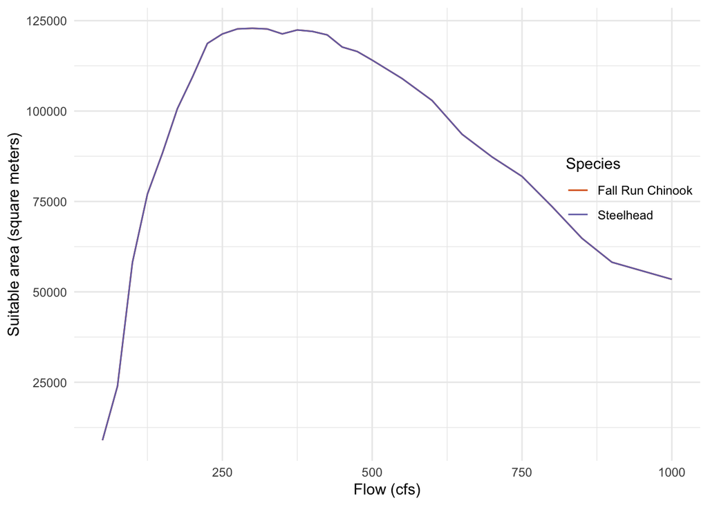

### Rearing Suitable Habitat

The following plot shows the rearing suitable area in square meters for Fall Run Chinook Salmon and Steelhead fry and juvenile. Data were provided for floodplain and instream rearing combined, so they were split between instream and floodplain using a floodplain cutoff value of `1000 cfs`.

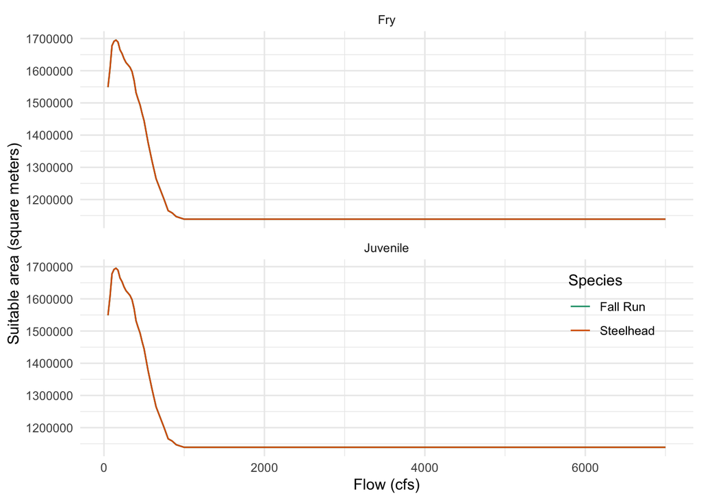

## Floodplain Rearing Habitat

## Floodplain Data

The areas are represented in suitable acres. Data in the rearing curve above `1000 cfs` were used to generate the flow-to-suitable area curve; values under `1000 cfs` were set to `0` for floodplain.

Header Descriptions: flow_cfs = flow in cubic feet per second, FR_floodplain_acres = Fall Run Chinook floodplain acres, SR_floodplain_acres = Spring Run Chinook floodplain acres, ST_floodplain_acres = Steelhead floodplain acres, watershed = section of stream modeled for CVPIA SDM

| flow_cfs | FR_floodplain_acres | SR_floodplain_acres | ST_floodplain_acres | watershed |
| --- | --- | --- | --- | --- |
| 1000 | 0.00 | 0.00 | 0.00 | Tuolumne River |
| 1250 | 35.96 | 35.96 | 35.96 | Tuolumne River |
| 1500 | 76.68 | 76.68 | 76.68 | Tuolumne River |
| 1750 | 116.87 | 116.87 | 116.87 | Tuolumne River |
| 2000 | 156.86 | 156.86 | 156.86 | Tuolumne River |

*… with 28 more rows*

## Floodplain Plot

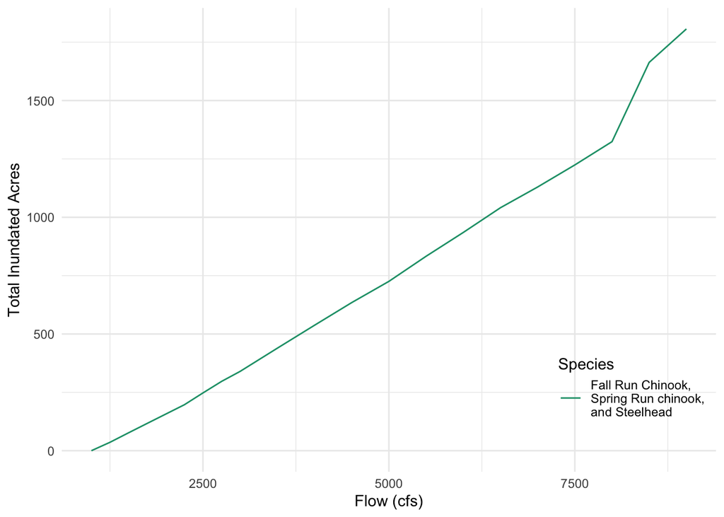